# Comparison escapees vs non-escapees

# 1. Data loading and fast exploration by PCA

Loading bsseq objects

```r
bsseq_obj <- readRDS("~/DataDir/1.PreliminaryAnalysis/Output/WithSelectedEGCLCs/bsseq_obj_sharedby75ofall.rds") #getting bsseq object where sample selection and CpG filtering were already performed
bsseq_obj_escapees <- readRDS(paste0(params$InputFolder, "bsseq_obj_escapees.rds"))
bsseq_obj_NonEscapees <- readRDS(paste0(params$InputFolder, "bsseq_obj_NonEscapees.rds"))
```

- Our bsseq object contain 3680616 CpG loci.
- Among them 9113 CpG loci belong to escapees regions (escapee CpGs).
- While 3671503 CpG loci do not belong to escapees regions (non-escapee CpGs).

**Colors for figures**

```r
cellTypes_colors <- c(hiPSCs ="#dd1c77", iMeLCs ="#377eb8", hPGCLCs ="#4daf4a", hEGCLCs = "#ff7f00")
```

## PCA only on escapee CpGs

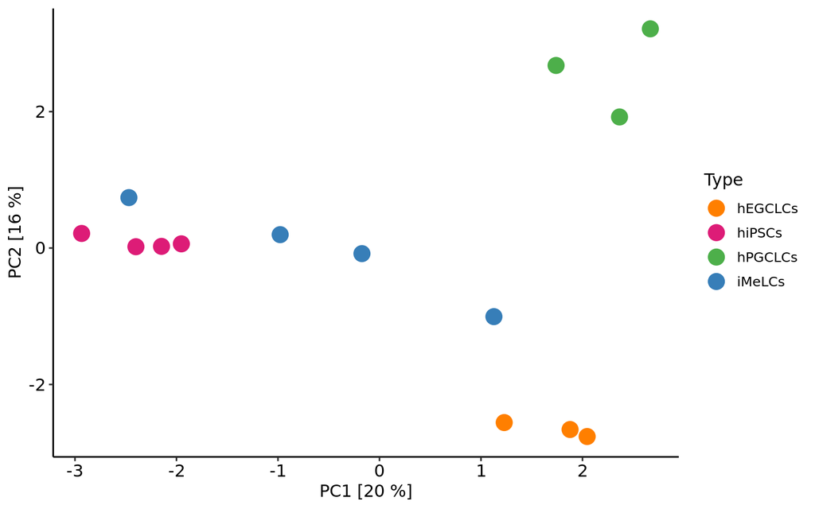

```r
pca_res <- do_PCA(getMeth(bsseq_obj_escapees, type = "raw"))
sample_anno <- bsseq::pData(bsseq_obj_escapees)
plot_PCA(pca_res = pca_res, anno = sample_anno, col_anno = "Type", shape_anno = NULL, custom_colors = cellTypes_colors, point_size = 5)
```

## PCA only on non-escapee CpGs

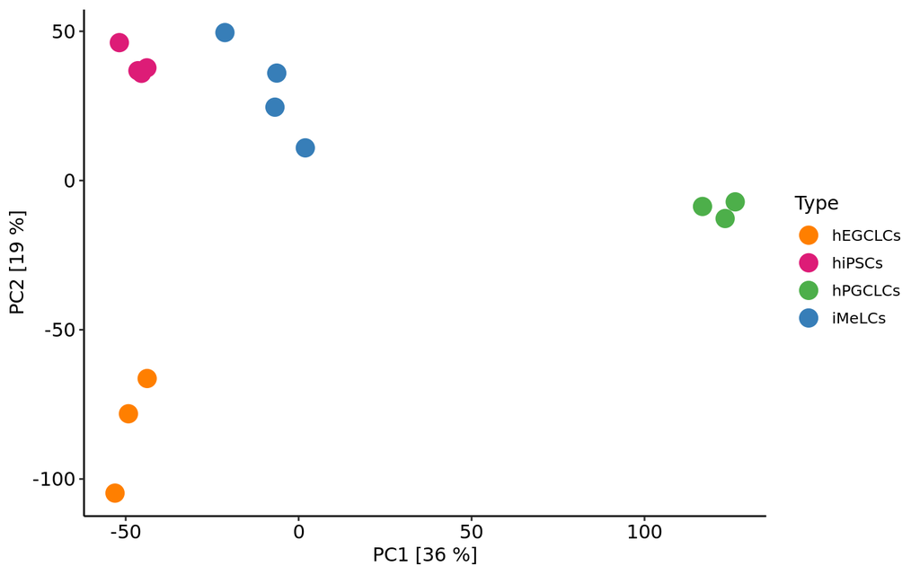

```r
pca_res <- do_PCA(getMeth(bsseq_obj_NonEscapees, type = "raw"))
sample_anno <- bsseq::pData(bsseq_obj_NonEscapees)
plot_PCA(pca_res = pca_res, anno = sample_anno, col_anno = "Type", shape_anno = NULL, custom_colors = cellTypes_colors, point_size = 5)
```

# 2.Generation of 500 random sets of 9113 non-escapee CpGs and distributions plots

Let’s generate random indices to randomly select 9113 CpG loci among the non-escapee ones.

```r
random_sets <- list()

for (i in 1:num_permutations) {
  random_indices <- sample(1:dim(bsseq_obj_NonEscapees)[1], dim(bsseq_obj_escapees)[1], replace = FALSE)
  bsseq_obj_randomNonEscapees <- bsseq_obj_NonEscapees[random_indices, ]

  random_sets[[i]] <- bsseq_obj_randomNonEscapees
}
```

**Head of BSSEQ with escapee CpGs**

```r
getMeth(bsseq_obj_escapees, type = "raw") %>% head()
```

```
##      hiPSC_rep1 hiPSC_rep2 hiPSC_rep3 hiPSC_rep4 iMeLC_rep1 iMeLC_rep2
## [1,]  0.9545455  0.9473684  0.9482759  0.9821429  0.9767442  0.9813084
## [2,]  1.0000000  0.9803922  0.9615385  0.9800000  0.9714286  0.9622642
## [3,]  0.8684211  0.9298246  0.7313433  0.8985507  0.9090909  0.7758621
## [4,]  0.8888889  0.9166667  0.8666667  0.9090909  0.9600000  0.8198198
## [5,]  0.7500000  0.8431373  0.8163265  0.7083333  0.8372093  0.8461538
## [6,]  0.8000000  0.8095238  0.8260870  0.8260870  0.8750000  0.6551724
##      iMeLC_rep3 iMeLC_rep4 hPGCLC_rep1 hPGCLC_rep2 hPGCLC_rep3 hEGCLC_rep1
## [1,]  0.8909091  0.9534884   0.9062500   1.0000000   0.9428571   0.9230769
## [2,]  0.9230769  0.9032258   0.9600000   0.9545455   0.9677419   0.9850746
## [3,]  0.7608696  0.8666667   0.8108108   0.6969697   0.7948718   0.8426966
## [4,]  0.8297872  0.8666667   0.8437500   0.7741935   0.8837209   0.8571429
## [5,]  0.7894737  0.7333333   0.7307692   0.7272727   0.8378378   0.7333333
## [6,]  0.9000000  0.8500000   0.8750000   0.8947368   0.6944444   0.7812500
##      hEGCLC_rep2 hEGCLC_rep3
## [1,]   0.9081633   0.9318182
## [2,]   0.9484536   0.9594595
## [3,]   0.8750000   0.8400000
## [4,]   0.8450704   0.8311688
## [5,]   0.6949153   0.8730159
## [6,]   0.7692308   0.8888889
```

**Escapee CpG methylation distribution plot**

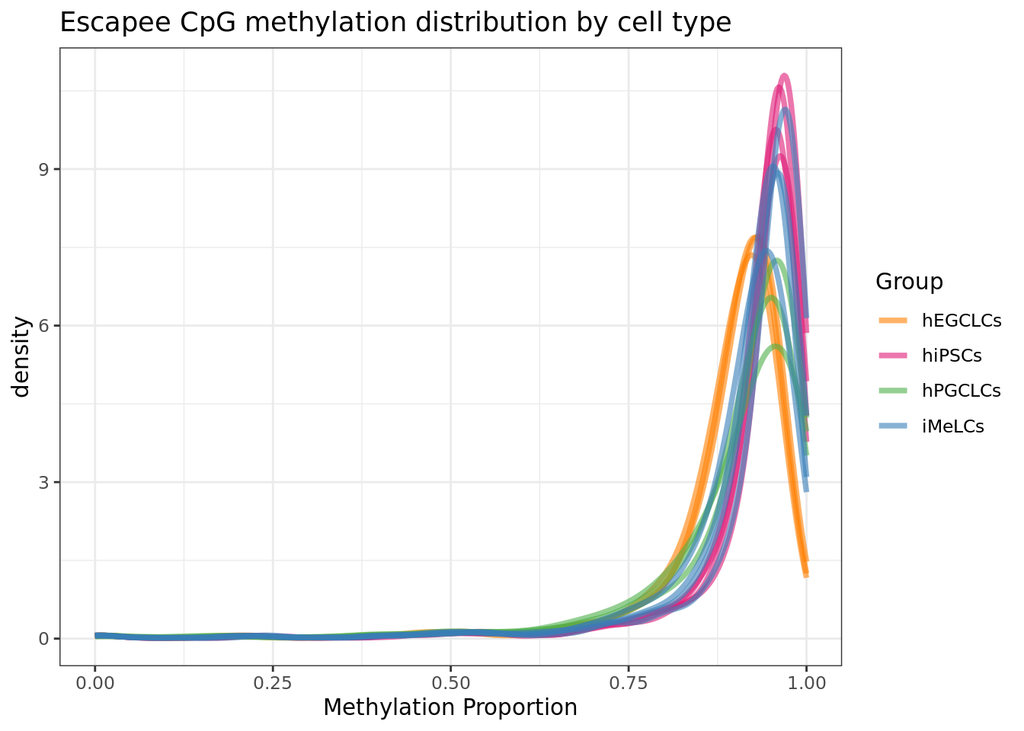

```r
plotEmpiricalDistribution(bsseq_obj_escapees,
                          bySample = TRUE,
                          testCovariate = "Type",
                          adj = 3) + guides(linetype="none") +
  labs(title = "Escapee CpG methylation distribution by cell type") + ggplot2::scale_color_manual(values = cellTypes_colors)
```

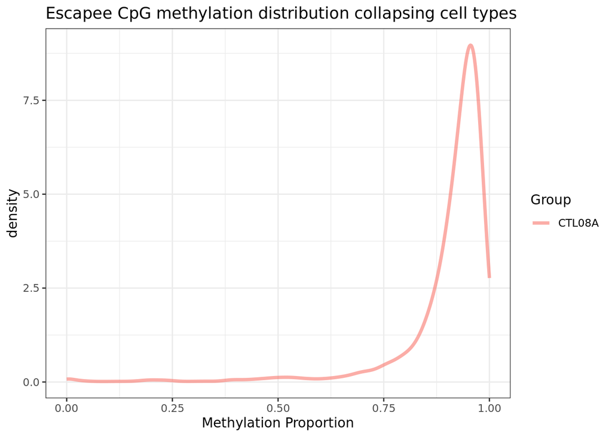

```r
plotEmpiricalDistribution(bsseq_obj_escapees,
                          bySample = FALSE,
                          testCovariate = "Line",
                          adj = 3) + guides(linetype="none") +
  labs(title = "Escapee CpG methylation distribution collapsing cell types")
```

**Non-Escapee CpG methylation distribution plot**

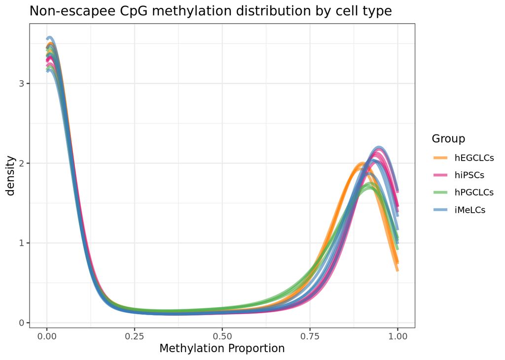

```r
plotEmpiricalDistribution(bsseq_obj_NonEscapees,
                          bySample = TRUE,
                          testCovariate = "Type",
                          adj = 3) + guides(linetype="none") +
  labs(title = "Non-escapee CpG methylation distribution by cell type") + ggplot2::scale_color_manual(values = cellTypes_colors)
```

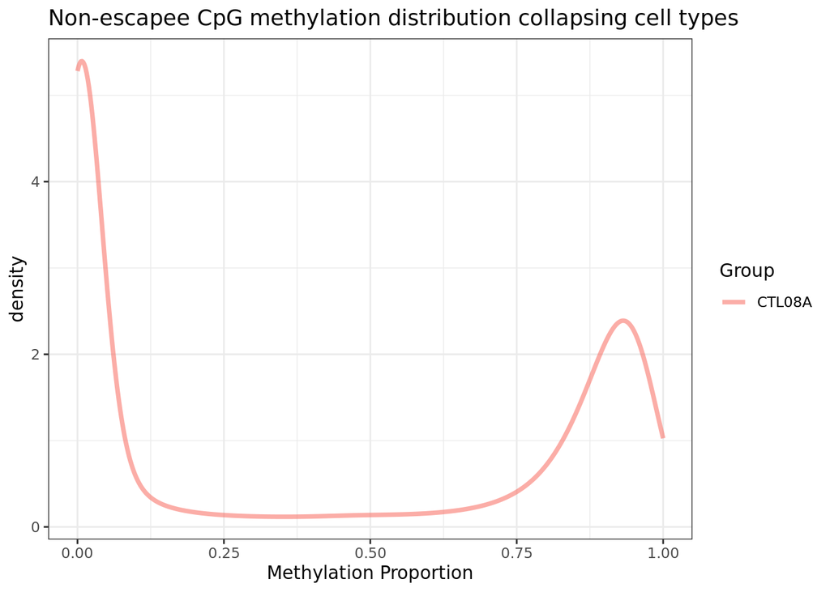

```r
plotEmpiricalDistribution(bsseq_obj_NonEscapees,
                          bySample = FALSE,
                          testCovariate = "Line",
                          adj = 3) + guides(linetype="none") +
  labs(title = "Non-escapee CpG methylation distribution collapsing cell types")
```

**Head of first BSSEQ with randomly selected non-escapee CpGs**

```r
getMeth(random_sets[[1]], type = "raw") %>% head()
```

```
##      hiPSC_rep1 hiPSC_rep2 hiPSC_rep3 hiPSC_rep4 iMeLC_rep1 iMeLC_rep2
## [1,]  1.0000000 0.95454545 0.93548387 0.90909091  0.9130435 0.87804878
## [2,]  0.8823529 0.94444444 0.90476190 0.87500000  0.9000000 0.84848485
## [3,]  0.3055556 0.13333333 0.21428571 0.21212121  0.2558140 0.25316456
## [4,]  0.1794872 0.08196721 0.08163265 0.06382979  0.1052632 0.08860759
## [5,]  0.7586207 0.96551724 1.00000000 0.94117647  0.8846154 0.88679245
## [6,]  0.9843750 0.96666667 0.93877551 0.96212121  0.9753086 0.97972973
##      iMeLC_rep3 iMeLC_rep4 hPGCLC_rep1 hPGCLC_rep2 hPGCLC_rep3 hEGCLC_rep1
## [1,]  0.9583333  1.0000000  0.88888889   0.9642857   0.9487179   0.9743590
## [2,]  0.8181818  0.7419355  0.86363636   0.9230769   0.9200000   0.8205128
## [3,]  0.1578947  0.1785714  0.20512821   0.1600000   0.1777778   0.2187500
## [4,]  0.1707317  0.1000000  0.02631579   0.1470588   0.1428571   0.1750000
## [5,]  0.8372093  0.7837838  0.83333333   0.7000000   0.6976744   0.9117647
## [6,]  1.0000000  0.9393939  0.96363636   0.9677419   0.9545455   0.9375000
##      hEGCLC_rep2 hEGCLC_rep3
## [1,]   0.8965517  0.94444444
## [2,]   0.7000000  0.82926829
## [3,]   0.1971831  0.20652174
## [4,]   0.1923077  0.07042254
## [5,]   0.9411765  0.84210526
## [6,]   1.0000000  0.95833333
```

**First set of randomly selected non-escapee CpG methylation distribution plot**

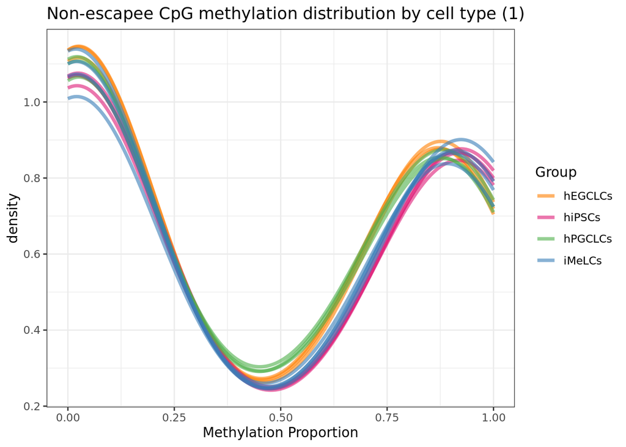

```r
plotEmpiricalDistribution(random_sets[[1]],
                          bySample = TRUE,
                          testCovariate = "Type",
                          adj = 3) + guides(linetype="none") +
  labs(title = "Non-escapee CpG methylation distribution by cell type (1)") + ggplot2::scale_color_manual(values = cellTypes_colors)
```

**Head of second BSSEQ with randomly selected non-escapee CpGs**

```r
getMeth(random_sets[[2]], type = "raw") %>% head()
```

```
##      hiPSC_rep1 hiPSC_rep2 hiPSC_rep3 hiPSC_rep4 iMeLC_rep1 iMeLC_rep2
## [1,]  1.0000000 0.94117647  1.0000000  0.9333333  0.9375000 1.00000000
## [2,]  0.9423077 0.89830508  0.8695652  0.8809524  0.8571429 0.86407767
## [3,]  0.0000000 0.02702703  0.0000000  0.0000000  0.0000000 0.04109589
## [4,]  0.8979592 0.93650794  0.8730159  0.9868421  0.9622642 0.93965517
## [5,]  0.6875000 0.93333333  1.0000000  0.9333333  0.8333333 0.80000000
## [6,]  0.9259259 0.97916667  0.9545455  0.9843750  0.9250000 0.91666667
##      iMeLC_rep3 iMeLC_rep4 hPGCLC_rep1 hPGCLC_rep2 hPGCLC_rep3 hEGCLC_rep1
## [1,]  0.8571429  0.9200000  0.82352941   1.0000000   0.8461538  0.97619048
## [2,]  0.8769231  0.9014085  0.88000000   0.8648649   0.9245283  0.87254902
## [3,]  0.0000000  0.0000000  0.04081633   0.0000000   0.0200000  0.01190476
## [4,]  0.9843750  0.9433962  0.90476190   0.9714286   0.9655172  0.88461538
## [5,]  0.9000000        NaN         NaN   0.5294118   0.2000000  0.78947368
## [6,]  0.9836066  0.8909091  0.91176471   0.8181818   0.9038462  0.81707317
##      hEGCLC_rep2 hEGCLC_rep3
## [1,]  0.79411765   0.8461538
## [2,]  0.82142857   0.8791209
## [3,]  0.01666667   0.0000000
## [4,]  0.89380531   0.9099099
## [5,]  0.84210526         NaN
## [6,]  0.92452830   0.9154930
```

**Second set of randomly selected non-escapee CpG methylation distribution plot**

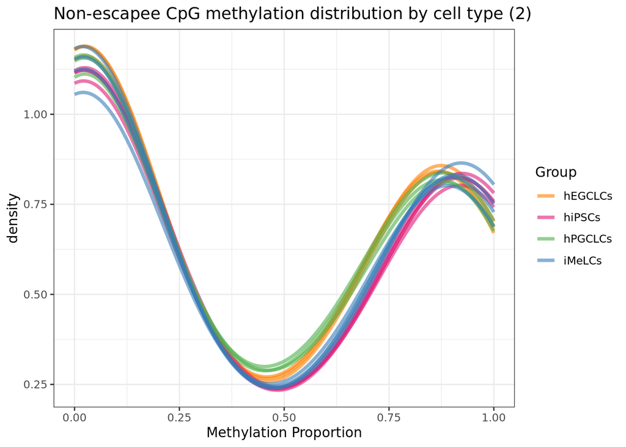

```r
plotEmpiricalDistribution(random_sets[[2]],
                          bySample = TRUE,
                          testCovariate = "Type",
                          adj = 3) + guides(linetype="none") +
  labs(title = "Non-escapee CpG methylation distribution by cell type (2)") + ggplot2::scale_color_manual(values = cellTypes_colors)
```

# 3. Kolmogorov-Smirnov test

Example of KS test result comparing distributions in case of hEGCLC_rep1 sample: escapee CpG methylation levels vs first randomly selected non-escapee set.

```r
ks_test_result <- ks.test(getMeth(bsseq_obj_escapees, type = "raw")[, "hEGCLC_rep1"], getMeth(random_sets[[1]], type = "raw")[, "hEGCLC_rep1"])
print(ks_test_result)
```

```
##
##  Asymptotic two-sample Kolmogorov-Smirnov test
##
## data:  getMeth(bsseq_obj_escapees, type = "raw")[, "hEGCLC_rep1"] and getMeth(random_sets[[1]], type = "raw")[, "hEGCLC_rep1"]
## D = 0.49116, p-value < 2.2e-16
## alternative hypothesis: two-sided
```

Example of KS test result comparing distributions in case of hEGCLC_rep1 sample: first randomly selected non-escapee set vs second randomly selected non-escapee set.

```r
ks_test_result <- ks.test(getMeth(random_sets[[1]], type = "raw")[, "hEGCLC_rep1"], getMeth(random_sets[[2]], type = "raw")[, "hEGCLC_rep1"])
print(ks_test_result)
```

```
##
##  Asymptotic two-sample Kolmogorov-Smirnov test
##
## data:  getMeth(random_sets[[1]], type = "raw")[, "hEGCLC_rep1"] and getMeth(random_sets[[2]], type = "raw")[, "hEGCLC_rep1"]
## D = 0.016899, p-value = 0.1481
## alternative hypothesis: two-sided
```

```r
ks_test_result <- ks.test(getMeth(random_sets[[1]], type = "raw")[, "hiPSC_rep2"], getMeth(random_sets[[1]], type = "raw")[, "hPGCLC_rep2"])
print(ks_test_result)
```

```
##
##  Asymptotic two-sample Kolmogorov-Smirnov test
##
## data:  getMeth(random_sets[[1]], type = "raw")[, "hiPSC_rep2"] and getMeth(random_sets[[1]], type = "raw")[, "hPGCLC_rep2"]
## D = 0.12607, p-value < 2.2e-16
## alternative hypothesis: two-sided
```

Example of KS test result comparing distributions: escapee CpG methylation levels vs first randomly selected non-escapee set **considering the mean levels across cell types (rowwise)**.

```r
ks_test_result <- ks.test(getMeth(bsseq_obj_escapees, type = "raw") %>% rowMeans(na.rm = TRUE), getMeth(random_sets[[1]], type = "raw") %>% rowMeans(na.rm = TRUE))
print(ks_test_result)
```

```
##
##  Asymptotic two-sample Kolmogorov-Smirnov test
##
## data:  getMeth(bsseq_obj_escapees, type = "raw") %>% rowMeans(na.rm = TRUE) and getMeth(random_sets[[1]], type = "raw") %>% rowMeans(na.rm = TRUE)
## D = 0.50247, p-value < 2.2e-16
## alternative hypothesis: two-sided
```

Example of KS test result comparing distributions: first randomly selected non-escapee set vs second randomly selected non-escapee set **considering the mean levels across cell types (rowwise)**.

```r
ks_test_result <- ks.test(getMeth(random_sets[[1]], type = "raw") %>% rowMeans(na.rm = TRUE), getMeth(random_sets[[2]], type = "raw") %>% rowMeans(na.rm = TRUE))
print(ks_test_result)
```

```
##
##  Asymptotic two-sample Kolmogorov-Smirnov test
##
## data:  getMeth(random_sets[[1]], type = "raw") %>% rowMeans(na.rm = TRUE) and getMeth(random_sets[[2]], type = "raw") %>% rowMeans(na.rm = TRUE)
## D = 0.020849, p-value = 0.03807
## alternative hypothesis: two-sided
```

*Let’s calculate the mean methylation levels across cell types in all sets of randomly selected non-escapee CpGs.*

```r
random_MeanMethLevels <- lapply(random_sets, function(bsseq){
  getMeth(bsseq, type = "raw") %>% rowMeans(na.rm = TRUE)})
```

**Let’s do KS test comparing escapee CpG methylation levels vs all 500 randomly selected non-escapee sets.**

```r
ks_test_results <- lapply(random_MeanMethLevels, function(random_MeanMeth) {
  ks.test(getMeth(bsseq_obj_escapees, type = "raw") %>% rowMeans(na.rm = TRUE), random_MeanMeth)
})
pvalues_kstest <- sapply(ks_test_results, function(result) {
  result$p.value
})
adjusted_pvalues_kstest <- p.adjust(pvalues_kstest, method = "fdr")
print(adjusted_pvalues_kstest)
```

```
##   [1] 0 0 0 0 0 0 0 0 0 0 0 0 0 0 0 0 0 0 0 0 0 0 0 0 0 0 0 0 0 0 0 0 0 0 0 0 0
##  [38] 0 0 0 0 0 0 0 0 0 0 0 0 0 0 0 0 0 0 0 0 0 0 0 0 0 0 0 0 0 0 0 0 0 0 0 0 0
##  [75] 0 0 0 0 0 0 0 0 0 0 0 0 0 0 0 0 0 0 0 0 0 0 0 0 0 0 0 0 0 0 0 0 0 0 0 0 0
## [112] 0 0 0 0 0 0 0 0 0 0 0 0 0 0 0 0 0 0 0 0 0 0 0 0 0 0 0 0 0 0 0 0 0 0 0 0 0
## [149] 0 0 0 0 0 0 0 0 0 0 0 0 0 0 0 0 0 0 0 0 0 0 0 0 0 0 0 0 0 0 0 0 0 0 0 0 0
## [186] 0 0 0 0 0 0 0 0 0 0 0 0 0 0 0 0 0 0 0 0 0 0 0 0 0 0 0 0 0 0 0 0 0 0 0 0 0
## [223] 0 0 0 0 0 0 0 0 0 0 0 0 0 0 0 0 0 0 0 0 0 0 0 0 0 0 0 0 0 0 0 0 0 0 0 0 0
## [260] 0 0 0 0 0 0 0 0 0 0 0 0 0 0 0 0 0 0 0 0 0 0 0 0 0 0 0 0 0 0 0 0 0 0 0 0 0
## [297] 0 0 0 0 0 0 0 0 0 0 0 0 0 0 0 0 0 0 0 0 0 0 0 0 0 0 0 0 0 0 0 0 0 0 0 0 0
## [334] 0 0 0 0 0 0 0 0 0 0 0 0 0 0 0 0 0 0 0 0 0 0 0 0 0 0 0 0 0 0 0 0 0 0 0 0 0
## [371] 0 0 0 0 0 0 0 0 0 0 0 0 0 0 0 0 0 0 0 0 0 0 0 0 0 0 0 0 0 0 0 0 0 0 0 0 0
## [408] 0 0 0 0 0 0 0 0 0 0 0 0 0 0 0 0 0 0 0 0 0 0 0 0 0 0 0 0 0 0 0 0 0 0 0 0 0
## [445] 0 0 0 0 0 0 0 0 0 0 0 0 0 0 0 0 0 0 0 0 0 0 0 0 0 0 0 0 0 0 0 0 0 0 0 0 0
## [482] 0 0 0 0 0 0 0 0 0 0 0 0 0 0 0 0 0 0 0
```

How many adjusted p-values are < 0.05?

```r
table(adjusted_pvalues_kstest < 0.05)
```

```
##
## TRUE
##  500
```

**Let’s do KS test comparing first randomly selected non-escapee set vs all 500 randomly selected non-escapee sets.**

```r
ks_test_results <- lapply(random_MeanMethLevels, function(random_MeanMeth) {
  ks.test(random_MeanMethLevels[[1]], random_MeanMeth)
})
pvalues_kstest <- sapply(ks_test_results, function(result) {
  result$p.value
})
adjusted_pvalues_kstest <- p.adjust(pvalues_kstest, method = "fdr")
print(adjusted_pvalues_kstest)
```

```
##   [1] 1.0000000 0.3518471 0.3847888 0.4303199 0.5205655 0.4407191 0.4442382
##   [8] 0.4407191 0.7503240 0.5407596 0.4407191 0.6083537 0.4375700 0.3422134
##  [15] 0.6768386 0.3422134 0.3578715 0.4755173 0.5488259 0.4438323 0.6736389
##  [22] 0.3847888 0.3353127 0.4585010 0.4159077 0.4159077 0.4303199 0.3422134
##  [29] 0.5148881 0.6915562 0.4271400 0.6867604 0.3578715 0.6083537 0.4442382
##  [36] 0.4823529 0.4407191 0.5381415 0.7503240 0.3432536 0.7134610 0.8199062
##  [43] 0.6915562 0.5999931 0.3518471 0.8720074 0.5148881 0.4407191 0.6318439
##  [50] 0.4442382 0.4303199 0.3353127 0.3818911 0.4303199 0.5286105 0.6385701
##  [57] 0.8491772 0.3422134 0.5074578 0.7816998 0.4823529 0.5286105 0.3706061
##  [64] 0.5286105 0.3422134 0.3518471 0.4459734 0.5585965 0.4823529 0.4194335
##  [71] 0.4066980 0.6867604 0.3012774 0.8807709 0.8491772 0.7261750 0.4755173
##  [78] 0.9930061 0.5407596 0.5381415 0.5900274 0.9049578 0.4856585 0.3432536
##  [85] 0.3706966 0.5766692 0.7503240 0.3578715 0.8000823 0.4303199 0.7497694
##  [92] 0.4271400 0.4585010 0.3899973 0.3578715 0.3847888 0.6318439 0.8427266
##  [99] 0.3899973 0.6768386 0.3606856 0.4066980 0.3432536 0.4541645 0.5407596
```

[output cut: 57 more lines]

How many adjusted p-values are < 0.05?

```r
table(adjusted_pvalues_kstest < 0.05)
```

```
##
## FALSE
##   500
```

# 4.Escapee and non escapee CpG methylation distribution plot

```r
MeanMethLevels_df <- c(unlist(random_MeanMethLevels), getMeth(bsseq_obj_escapees, type = "raw") %>% rowMeans(na.rm = TRUE) %>% as.vector()) %>% as.data.frame()
colnames(MeanMethLevels_df) <- "MeanMeth"
MeanMethLevels_df$Distribution <- c(paste0("Random_", rep(1:num_permutations, each = dim(bsseq_obj_escapees)[1])), rep("Escapees_CpGs", each = dim(bsseq_obj_escapees)[1]))
MeanMethLevels_df$Category <- "Non Escapees"
MeanMethLevels_df$Category[(nrow(MeanMethLevels_df)+1-nrow(bsseq_obj_escapees)):nrow(MeanMethLevels_df)] <- "Escapees"
```

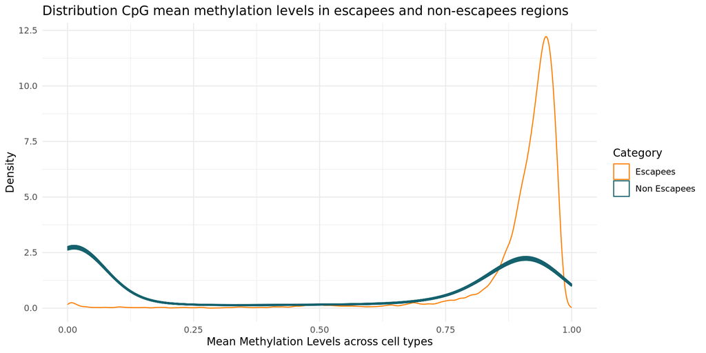

```r
ggplot(MeanMethLevels_df, aes(x = MeanMeth, color = Category, group = Distribution)) +
  geom_density(alpha = 0.5)  +
  labs(
    title = "Distribution CpG mean methylation levels in escapees and non-escapees regions",
    x = "Mean Methylation Levels across cell types",
    y = "Density",
    color = "Category"
  ) +
  scale_color_manual(values = c("Escapees" = "#FF7D00", "Non Escapees" = "#15616D")) +
  theme_minimal()
```

# 5.Session Info

```r
date()
## [1] "Tue Jan 28 16:52:36 2025"
sessionInfo()
## R version 4.2.1 (2022-06-23)
## Platform: x86_64-pc-linux-gnu (64-bit)
## Running under: Ubuntu 20.04.4 LTS
##
## Matrix products: default
## BLAS:   /usr/lib/x86_64-linux-gnu/blas/libblas.so.3.9.0
## LAPACK: /usr/lib/x86_64-linux-gnu/lapack/liblapack.so.3.9.0
##
## locale:
##  [1] LC_CTYPE=en_US.UTF-8       LC_NUMERIC=C
##  [3] LC_TIME=en_US.UTF-8        LC_COLLATE=en_US.UTF-8
##  [5] LC_MONETARY=en_US.UTF-8    LC_MESSAGES=en_US.UTF-8
##  [7] LC_PAPER=en_US.UTF-8       LC_NAME=C
##  [9] LC_ADDRESS=C               LC_TELEPHONE=C
## [11] LC_MEASUREMENT=en_US.UTF-8 LC_IDENTIFICATION=C
##
## attached base packages:
## [1] stats4    stats     graphics  grDevices utils     datasets  methods
## [8] base
##
## other attached packages:
##  [1] tidyr_1.3.0                 ggplot2_3.4.2
##  [3] dmrseq_1.18.1               bsseq_1.34.0
##  [5] SummarizedExperiment_1.28.0 Biobase_2.58.0
##  [7] MatrixGenerics_1.10.0       matrixStats_1.0.0
##  [9] GenomicRanges_1.50.2        GenomeInfoDb_1.34.9
## [11] IRanges_2.32.0              S4Vectors_0.36.2
## [13] BiocGenerics_0.44.0         dplyr_1.1.2
## [15] plyr_1.8.8
##
## loaded via a namespace (and not attached):
##   [1] AnnotationHub_3.6.0           BiocFileCache_2.6.1
##   [3] splines_4.2.1                 BiocParallel_1.32.6
##   [5] digest_0.6.33                 foreach_1.5.2
##   [7] htmltools_0.5.5               fansi_1.0.4
##   [9] magrittr_2.0.3                memoise_2.0.1
##  [11] BSgenome_1.66.3               tzdb_0.4.0
##  [13] limma_3.54.2                  Biostrings_2.66.0
##  [15] readr_2.1.4                   R.utils_2.12.2
##  [17] prettyunits_1.1.1             colorspace_2.1-0
##  [19] blob_1.2.4                    rappdirs_0.3.3
##  [21] xfun_0.39                     crayon_1.5.2
##  [23] RCurl_1.98-1.12               jsonlite_1.8.7
##  [25] annotatr_1.24.0               iterators_1.0.14
##  [27] glue_1.6.2                    gtable_0.3.3
##  [29] zlibbioc_1.44.0               XVector_0.38.0
##  [31] DelayedArray_0.24.0           Rhdf5lib_1.20.0
##  [33] HDF5Array_1.26.0              scales_1.2.1
##  [35] DBI_1.1.3                     rngtools_1.5.2
##  [37] Rcpp_1.0.11                   xtable_1.8-4
##  [39] progress_1.2.2                bumphunter_1.40.0
##  [41] bit_4.0.5                     httr_1.4.6
##  [43] RColorBrewer_1.1-3            ellipsis_0.3.2
##  [45] pkgconfig_2.0.3               XML_3.99-0.14
##  [47] R.methodsS3_1.8.2             farver_2.1.1
##  [49] sass_0.4.7                    dbplyr_2.3.3
##  [51] locfit_1.5-9.7                utf8_1.2.3
##  [53] tidyselect_1.2.0              labeling_0.4.2
##  [55] rlang_1.1.1                   reshape2_1.4.4
##  [57] later_1.3.1                   AnnotationDbi_1.60.2
##  [59] munsell_0.5.0                 BiocVersion_3.16.0
##  [61] tools_4.2.1                   cachem_1.0.8
##  [63] cli_3.6.1                     generics_0.1.3
##  [65] RSQLite_2.3.1                 evaluate_0.21
##  [67] stringr_1.5.0                 fastmap_1.1.1
##  [69] yaml_2.3.7                    outliers_0.15
##  [71] knitr_1.43                    bit64_4.0.5
##  [73] purrr_1.0.1                   KEGGREST_1.38.0
##  [75] nlme_3.1-162                  doRNG_1.8.6
##  [77] sparseMatrixStats_1.10.0      mime_0.12
##  [79] R.oo_1.25.0                   xml2_1.3.5
##  [81] biomaRt_2.54.1                compiler_4.2.1
##  [83] rstudioapi_0.15.0             filelock_1.0.2
##  [85] curl_5.0.1                    png_0.1-8
##  [87] interactiveDisplayBase_1.36.0 tibble_3.2.1
##  [89] bslib_0.5.0                   stringi_1.7.12
##  [91] highr_0.10                    GenomicFeatures_1.50.4
##  [93] lattice_0.21-8                Matrix_1.6-0
##  [95] permute_0.9-7                 vctrs_0.6.3
##  [97] pillar_1.9.0                  lifecycle_1.0.3
##  [99] rhdf5filters_1.10.1           BiocManager_1.30.20
## [101] jquerylib_0.1.4               data.table_1.14.8
## [103] bitops_1.0-7                  httpuv_1.6.11
## [105] rtracklayer_1.58.0            R6_2.5.1
## [107] BiocIO_1.8.0                  promises_1.2.0.1
## [109] codetools_0.2-19              gtools_3.9.4
## [111] rhdf5_2.42.1                  rjson_0.2.21
## [113] withr_2.5.0                   regioneR_1.30.0
## [115] GenomicAlignments_1.34.1      Rsamtools_2.14.0
## [117] GenomeInfoDbData_1.2.9        parallel_4.2.1
## [119] hms_1.1.3                     grid_4.2.1
## [121] rmarkdown_2.23                DelayedMatrixStats_1.20.0
## [123] shiny_1.7.4.1                 restfulr_0.0.15
```